# Concentration of S&P 500 index

Maroan Mejric

In this data challenge we study how concentrated the S&P 500 is among its constituent companies.

1. The S&P 500 (Standard & Poor’s 500) is a stock market index that tracks the performance of 500 of the largest publicly traded companies in the United States.
2. It covers roughly 80% of the total value of the U.S. stock market.
3. It is a market-capitalization-weighted index. Larger companies have a much bigger impact on its value than smaller components

We will use:

```r
library(tidyverse)
library(tidyquant)
library(ineq)
```

The three packages have different roles:

```
tidyquant    retrieve the S&P 500 constituents and weights
tidyverse    manipulate and visualize the data
ineq         calculate the Lorenz curve and Gini coefficient
```

## Retrieve the constituents

The function `tq_index()` returns the constituents of the S&P 500 as a tibble, with the weight of each company in the index:

```r
sp500 = tq_index("SP500")
sp500
```

```
## # A tibble: 505 × 8
##    symbol company      identifier sedol weight sector shares_held local_currency
##    <chr>  <chr>        <chr>      <chr>  <dbl> <chr>        <dbl> <chr>
##  1 NVDA   NVIDIA CORP  67066G104  2379… 0.0786 -        296896008 USD
##  2 AAPL   APPLE INC    037833100  2046… 0.0746 -        179048125 USD
##  3 MSFT   MICROSOFT C… 594918104  2588… 0.0599 -         91093672 USD
##  4 AMZN   AMAZON.COM … 023135106  2000… 0.0374 -        120415462 USD
##  5 GOOGL  ALPHABET IN… 02079K305  BYVY… 0.0306 -         71988357 USD
##  6 GOOG   ALPHABET IN… 02079K107  BYY8… 0.0245 -         58313497 USD
##  7 AVGO   BROADCOM INC 11135F101  BDZ7… 0.0245 -         58366639 USD
##  8 META   META PLATFO… 30303M102  B7TL… 0.0243 -         27052883 USD
##  9 MU     MICRON TECH… 595112103  2588… 0.0157 -         13855958 USD
## 10 TSLA   TESLA INC    88160R101  B616… 0.0153 -         34576518 USD
## # ℹ 495 more rows
```

```r
# keep companies with a valid weight, sorted by weight
sp500 =
  sp500 |>
  filter(!is.na(weight)) |>
  arrange(desc(weight))

# number of constituents and sum of weights
nrow(sp500)
```

```
## [1] 505
```

```r
sum(sp500$weight)
```

```
## [1] 1
```

## 1. How unequal are the company weights?

```r
summary(sp500$weight)
```

```
##      Min.   1st Qu.    Median      Mean   3rd Qu.      Max.
## 3.000e-08 3.085e-04 6.527e-04 1.980e-03 1.339e-03 7.861e-02
```

```r
# the largest and smallest companies
head(sp500 |> select(symbol, company, weight), 10)
```

```
## # A tibble: 10 × 3
##    symbol company                    weight
##    <chr>  <chr>                       <dbl>
##  1 NVDA   NVIDIA CORP                0.0786
##  2 AAPL   APPLE INC                  0.0746
##  3 MSFT   MICROSOFT CORP             0.0599
##  4 AMZN   AMAZON.COM INC             0.0374
##  5 GOOGL  ALPHABET INC CL A          0.0306
##  6 GOOG   ALPHABET INC CL C          0.0245
##  7 AVGO   BROADCOM INC               0.0245
##  8 META   META PLATFORMS INC CLASS A 0.0243
##  9 MU     MICRON TECHNOLOGY INC      0.0157
## 10 TSLA   TESLA INC                  0.0153
```

```r
tail(sp500 |> select(symbol, company, weight), 10)
```

```
## # A tibble: 10 × 3
##    symbol   company                           weight
##    <chr>    <chr>                              <dbl>
##  1 DVA      DAVITA INC                  0.0000957
##  2 MOS      MOSAIC CO/THE               0.0000909
##  3 ERIE     ERIE INDEMNITY COMPANY CL A 0.0000908
##  4 HRL      HORMEL FOODS CORP           0.0000882
##  5 WYNN     WYNN RESORTS LTD            0.0000822
##  6 MGM      MGM RESORTS INTERNATIONAL   0.0000776
##  7 BF-B     BROWN FORMAN CORP CLASS B   0.0000756
##  8 NWS      NEWS CORP   CLASS B         0.0000604
##  9 SKYD     SKYDANCE CORP               0.0000592
## 10 2602335D TPG INC                     0.0000000299
```

```r
# ratio between the largest and the smallest weight
max(sp500$weight) / min(sp500$weight)
```

```
## [1] 2625880
```

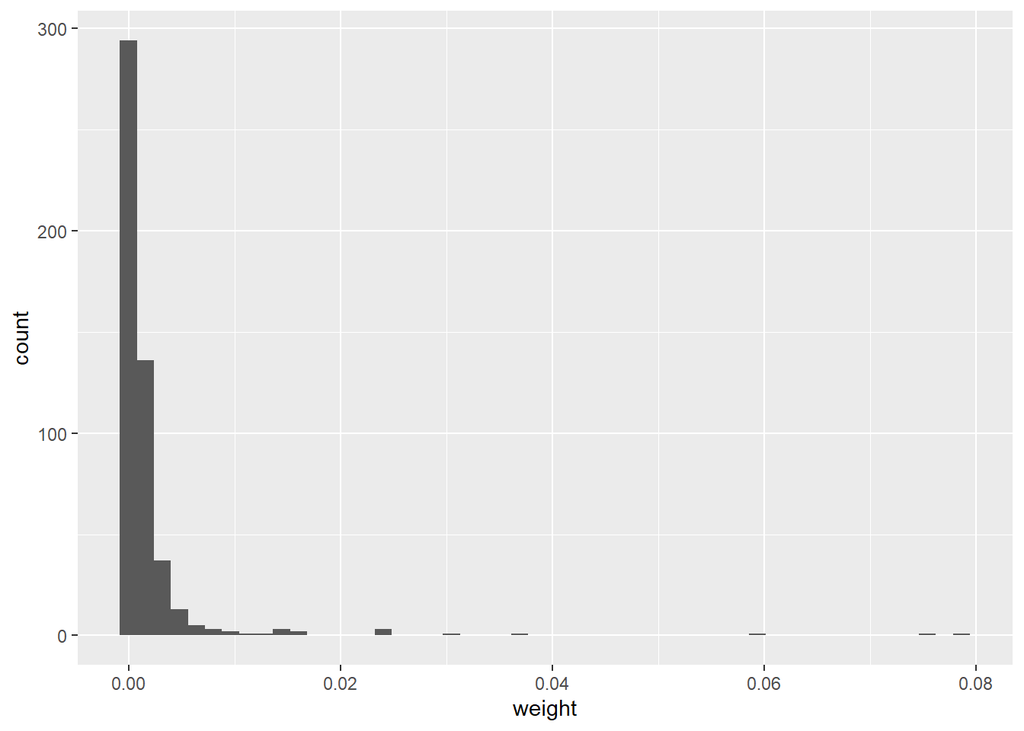

```r
# distribution of weights
ggplot(sp500, aes(weight)) +
  geom_histogram(bins = 50)
```

The weights are highly unequal: the mean is much larger than the median, the distribution is right skewed with a long tail of a few companies with very large weights.

## 2. How much of the index is represented by its largest companies?

```r
# cumulative weight of the largest companies
concentration =
  sp500 |>
  mutate(rank = row_number(), cumulative_weight = cumsum(weight)) |>
  select(rank, symbol, company, weight, cumulative_weight)

concentration |>
  filter(rank %in% c(1, 5, 10, 20, 50, 100, 250))
```

```
## # A tibble: 7 × 5
##    rank symbol company                       weight cumulative_weight
##   <int> <chr>  <chr>                          <dbl>             <dbl>
## 1     1 NVDA   NVIDIA CORP                 0.0786              0.0786
## 2     5 GOOGL  ALPHABET INC CL A           0.0306              0.281
## 3    10 TSLA   TESLA INC                   0.0153              0.385
## 4    20 MA     MASTERCARD INC   A          0.00745             0.495
## 5    50 IBM    INTL BUSINESS MACHINES CORP 0.00330             0.637
## 6   100 PLD    PROLOGIS INC                0.00180             0.757
## 7   250 OXY    OCCIDENTAL PETROLEUM CORP   0.000660            0.915
```

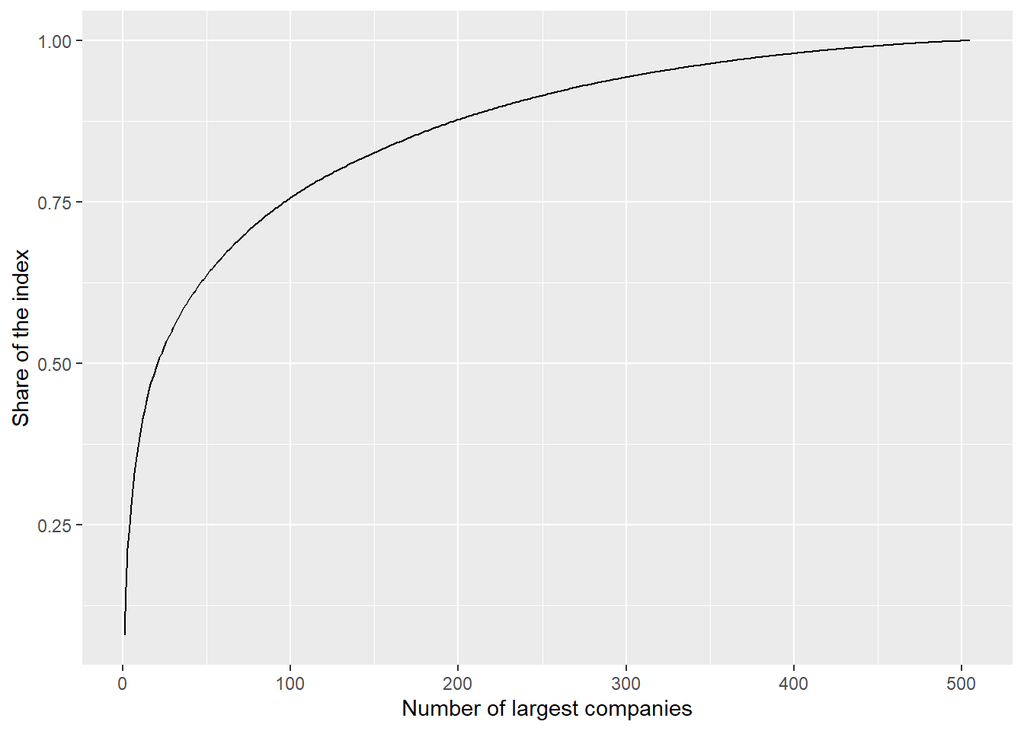

```r
# plot the cumulative weight
ggplot(concentration, aes(rank, cumulative_weight)) +
  geom_line() +
  labs(x = "Number of largest companies", y = "Share of the index")
```

A handful of companies represents a large share of the index: the 10 largest companies alone represent almost 40% of the index, the 20 largest about half of it, and 100 companies out of about 500 represent three quarters of it.

## 3. What does the Lorenz curve tell us about concentration?

The Lorenz curve plots the cumulative share of the index held by the cumulative share of companies, from the smallest to the largest. The diagonal corresponds to perfect equality (all companies with the same weight), while the more the curve bends away from the diagonal, the more concentrated the index is.

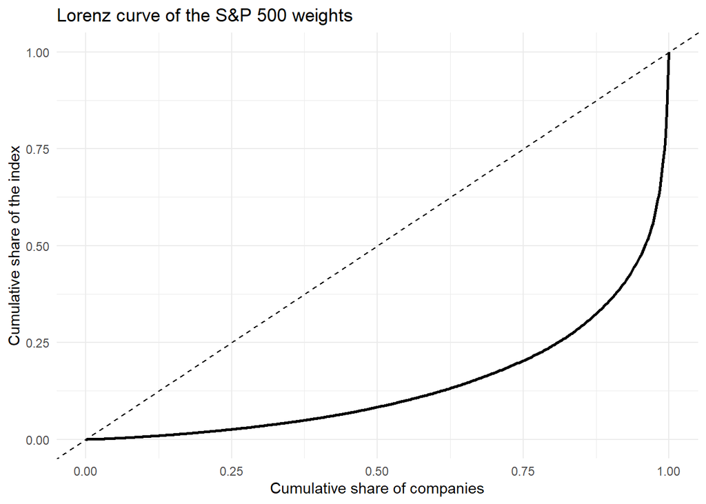

```r
lorenz = Lc(sp500$weight)

df_lorenz = data.frame(p = lorenz$p, L = lorenz$L)

ggplot(df_lorenz, aes(p, L)) +
  geom_line(linewidth = 1) +
  geom_abline(slope = 1, intercept = 0, linetype = "dashed") +
  labs(
    title = "Lorenz curve of the S&P 500 weights",
    x = "Cumulative share of companies",
    y = "Cumulative share of the index"
  ) +
  theme_minimal()
```

The curve lies well below the diagonal: the smallest half of the companies holds only a small fraction of the index, while the last few percent of companies hold a large fraction of it.

## 4. What is the Gini coefficient of the S&P 500 weights?

The Gini coefficient is twice the area between the Lorenz curve and the diagonal: it is 0 for perfect equality and tends to 1 for maximum concentration.

```r
Gini(sp500$weight)
```

```
## [1] 0.7177434
```

The Gini coefficient confirms that the S&P 500 is a concentrated index, although the concentration is lower than that of the voting power in the ENS DAO case seen in class (where the Gini index was above 0.9).